# Severe weather impact in USA (1950-2011)

Agustin González-Quel

28 de abril de 2016

# Impact of Severe Weather in USA

## The problem to analyse

Storms and other severe weather events can cause both public health and economic problems for communities and municipalities. Many severe events can result in fatalities, injuries, and property damage, and preventing such outcomes to the extent possible is a key concern.

This project involves exploring the U.S. National Oceanic and Atmospheric Administration’s (NOAA) storm database. This database tracks characteristics of major storms and weather events in the United States, including when and where they occur, as well as estimates of any fatalities, injuries, and property damage.

The data used for this research in the form of a comma-separated-value file compressed via the bzip2 algorithm (47Mb file)

[Storm Data](https://d396qusza40orc.cloudfront.net/repdata%2Fdata%2FStormData.csv.bz2)

Additional information required for data processing can be found at the [Storm Events](http://www.ncdc.noaa.gov/stormevents/) page at [NOAA website](http://www.ncdc.noaa.gov/)

### Questions to be answered

Which types of events are most harmful with respect to population health? Which types of events have the greatest economic consequences?

## Analysis carried out

The analysis carried out is included herebelow. The process starts by loading the data into de R working environment. Afterwards some data cleaning is required to have datasets that can be managed in a more efficient way. Finally, the analysis itself is presented. All the steps carried out are described in detail so the process can be easily reproduced using similar datasets.

### Preliminary steps

For this analysis a number of libraries are required. They are loaded initially in the working environment

```r
library(ggplot2)
library(gridExtra)
library(reshape2)
```

### Data acquisition

Loading Data

```r
download.file("https://d396qusza40orc.cloudfront.net/repdata%2Fdata%2FStormData.csv.bz2", "mystormdata.csv.bz2")

myStormData <- read.csv(bzfile("mystormdata.csv.bz2"))
dim(myStormData)
```

```
## [1] 902297     37
```

The obtained data frame has 37 columns and 902297 rows. Names of the columns are presented for the researcher to select the data that will be used by further subsetting the data frame

```r
names(myStormData)
```

```
##  [1] "STATE__"    "BGN_DATE"   "BGN_TIME"   "TIME_ZONE"  "COUNTY"
##  [6] "COUNTYNAME" "STATE"      "EVTYPE"     "BGN_RANGE"  "BGN_AZI"
## [11] "BGN_LOCATI" "END_DATE"   "END_TIME"   "COUNTY_END" "COUNTYENDN"
## [16] "END_RANGE"  "END_AZI"    "END_LOCATI" "LENGTH"     "WIDTH"
## [21] "F"          "MAG"        "FATALITIES" "INJURIES"   "PROPDMG"
## [26] "PROPDMGEXP" "CROPDMG"    "CROPDMGEXP" "WFO"        "STATEOFFIC"
## [31] "ZONENAMES"  "LATITUDE"   "LONGITUDE"  "LATITUDE_E" "LONGITUDE_"
## [36] "REMARKS"    "REFNUM"
```

### Data Processing

From the 37 variables, a number of them are selected for this research:

- BGN_DATE: Date.
- EVTYPE: Type of weather event.
- FATALITIES: Number of fatalities.
- INJURIES: Number of injuries.
- PROPDMG: Figure of the property damage (E.g. 34)
- PROPDMGEXP: Expontential notation that complement the previous (e.g. K This means 34 K$)
- CROPDMG: Figure fpr the crop damage (E.g. 13).
- CROPDMGEXP: Expontential notation that complement the previous (e.g. M This means 13.000.000 $)

```r
mySubsetStormData <- myStormData[c("BGN_DATE","EVTYPE","FATALITIES","INJURIES","PROPDMG","PROPDMGEXP","CROPDMG","CROPDMGEXP")]
```

At this point we have reduced the number of variables to those really required for our analysis.

An additional step is to convert PROPDMGEXP and CROPDMGEXP from exponential notation to numbers. For that purpose a couple of functions are created and then called

```r
propExp2number <- function(df) {
    library(plyr)
    df$PROPex <- df$PROPDMGEXP
    df$PROPex <- revalue(df$PROPex, c("K"="3","M"="6","m"="6","B"="9","+"="0","h"="2","H"="2","-"="0","?"="0"))
    df$PROPex[df$PROPex==""] <- "0"
    df$PROPex<-as.numeric(df$PROPex)
    df$TOTALPROPDMG <- df$PROPDMG * (10^df$PROPex)
    df
}

cropExp2number <- function(df) {
    library(plyr)
    df$CROPex <- df$CROPDMGEXP
    df$CROPex <- revalue(df$CROPex, c("K"="3","M"="6","m"="6","B"="9","+"="0","h"="2","H"="2","-"="0","?"="0"))
    df$CROPex[df$CROPex==""] <- "0"
    df$CROPex<-as.numeric(df$CROPex)
    df$TOTALCROPDMG <- df$CROPDMG * (10^df$CROPex)
    df
}

mySubsetStormData <- propExp2number(mySubsetStormData)
mySubsetStormData <- cropExp2number(mySubsetStormData)
```

Again, we restrict the dataframe to the variables that are relevant for our research. As we have the total figure for damages we can remove the two initial variables.

```r
mySubsetStormData <- mySubsetStormData[c("BGN_DATE","EVTYPE","FATALITIES","INJURIES","TOTALPROPDMG","TOTALCROPDMG")]
```

A look to the subsetted dataframe

```r
dim(mySubsetStormData)
```

```
## [1] 902297      6
```

```r
summary(mySubsetStormData)
```

```
##               BGN_DATE                    EVTYPE         FATALITIES
##  5/25/2011 0:00:00:  1202   HAIL             :288661   Min.   :  0.0000
##  4/27/2011 0:00:00:  1193   TSTM WIND        :219940   1st Qu.:  0.0000
##  6/9/2011 0:00:00 :  1030   THUNDERSTORM WIND: 82563   Median :  0.0000
##  5/30/2004 0:00:00:  1016   TORNADO          : 60652   Mean   :  0.0168
##  4/4/2011 0:00:00 :  1009   FLASH FLOOD      : 54277   3rd Qu.:  0.0000
##  4/2/2006 0:00:00 :   981   FLOOD            : 25326   Max.   :583.0000
##  (Other)          :895866   (Other)          :170878
##     INJURIES          TOTALPROPDMG        TOTALCROPDMG
##  Min.   :   0.0000   Min.   :0.000e+00   Min.   :0.000e+00
##  1st Qu.:   0.0000   1st Qu.:0.000e+00   1st Qu.:0.000e+00
##  Median :   0.0000   Median :0.000e+00   Median :0.000e+00
##  Mean   :   0.1557   Mean   :4.746e+07   Mean   :1.867e+06
##  3rd Qu.:   0.0000   3rd Qu.:5.000e+04   3rd Qu.:0.000e+00
##  Max.   :1700.0000   Max.   :1.150e+13   Max.   :5.960e+09
##
```

```r
mySubsetStormData[800000:800010,]
```

```
##                 BGN_DATE            EVTYPE FATALITIES INJURIES
## 800000  4/6/2010 0:00:00 THUNDERSTORM WIND          0        0
## 800001  4/6/2010 0:00:00 THUNDERSTORM WIND          0        0
## 800002  4/6/2010 0:00:00 THUNDERSTORM WIND          0        0
## 800003  4/5/2010 0:00:00              HAIL          0        0
## 800004  4/5/2010 0:00:00              HAIL          0        0
## 800005 4/23/2010 0:00:00 THUNDERSTORM WIND          0        0
## 800006 4/23/2010 0:00:00              HAIL          0        0
## 800007 4/23/2010 0:00:00              HAIL          0        0
## 800008  4/5/2010 0:00:00              HAIL          0        0
## 800009  4/2/2010 0:00:00 THUNDERSTORM WIND          0        0
## 800010  4/2/2010 0:00:00 THUNDERSTORM WIND          0        0
##        TOTALPROPDMG TOTALCROPDMG
## 800000            0            0
## 800001            0            0
## 800002            0            0
## 800003            0            0
## 800004            0            0
## 800005            0            0
## 800006            0            0
## 800007            0            0
## 800008            0            0
## 800009      2000000            0
## 800010      2500000            0
```

At this point, the dataframe mySubsetStormData is prepared to answer the questions of the study

## Results

The results of the study are presented herebelow

### Which events are more harmful with respect to population health

Both death and injured people are included in this group

The strategy followed is to agregate data by fatalities and injuries

```r
totalFatalities <- aggregate(FATALITIES~EVTYPE, data = mySubsetStormData, "sum")
totalInjuries <- aggregate(INJURIES~EVTYPE, data = mySubsetStormData, "sum")
```

Now both dataframes are merged

```r
totalDamagedPeople <- merge(totalFatalities, totalInjuries, by = 'EVTYPE')
```

And we take the 10 events type that account more harmful events (fatalities and injuries) and present the results

```r
totalDamagedPeople <- totalDamagedPeople[order(-(totalDamagedPeople$FATALITIES+totalDamagedPeople$INJURIES)),]
totalDamagedPeople <- totalDamagedPeople[1:10,]
totalDamagedPeople
```

```
##                EVTYPE FATALITIES INJURIES
## 834           TORNADO       5633    91346
## 130    EXCESSIVE HEAT       1903     6525
## 856         TSTM WIND        504     6957
## 170             FLOOD        470     6789
## 464         LIGHTNING        816     5230
## 275              HEAT        937     2100
## 153       FLASH FLOOD        978     1777
## 427         ICE STORM         89     1975
## 760 THUNDERSTORM WIND        133     1488
## 972      WINTER STORM        206     1321
```

A graphical representation for results

Graphical representation of data as they are would lead to a hard to read chart, as the difference among numbers is very high. Therefore, we propose a different representation using a logarithmic scale

```r
library(reshape)
```

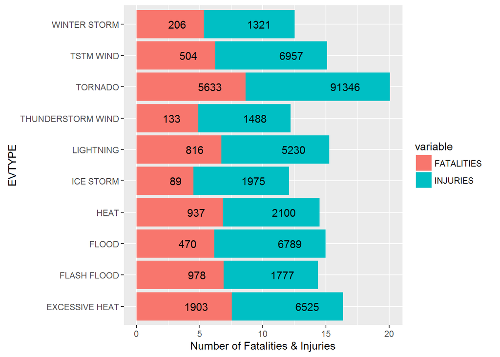

```r
damagedPeople <- melt(totalDamagedPeople, id.var = 'EVTYPE')
ggplot(damagedPeople, aes(EVTYPE, y = log(value+1), fill = variable)) + geom_bar(stat="identity") +
       geom_bar(stat="identity", position="stack") +
       geom_text(aes(label=value), position="stack", hjust=2) +
       scale_y_continuous(name="Number of Fatalities & Injuries")+
       coord_flip()
```

### Events with greatest economic consequences

The available information is used now to research on economical consequences

First of all, Properties:

```r
damagedProps <- aggregate(TOTALPROPDMG~EVTYPE, data = mySubsetStormData, "sum")
damagedProps <- damagedProps[order(-(damagedProps$TOTALPROPDMG)),]
damagedProps <- damagedProps[1:10,]
damagedProps
```

```
##                EVTYPE TOTALPROPDMG
## 170             FLOOD 1.446577e+13
## 411 HURRICANE/TYPHOON 6.930584e+12
## 834           TORNADO 5.694738e+12
## 670       STORM SURGE 4.332354e+12
## 153       FLASH FLOOD 1.682267e+12
## 244              HAIL 1.573527e+12
## 402         HURRICANE 1.186832e+12
## 848    TROPICAL STORM 7.703891e+11
## 972      WINTER STORM 6.688497e+11
## 359         HIGH WIND 5.270046e+11
```

Then, Crops:

```r
damagedCrops <- aggregate(TOTALCROPDMG~EVTYPE, data = mySubsetStormData, "sum")
damagedCrops <- damagedCrops[order(-(damagedCrops$TOTALCROPDMG)),]
damagedCrops <- damagedCrops[1:10,]
damagedCrops
```

```
##                 EVTYPE TOTALCROPDMG
## 244               HAIL 601237452300
## 170              FLOOD 217532750000
## 153        FLASH FLOOD 190390700000
## 95             DROUGHT 145957215000
## 856          TSTM WIND 113209850000
## 834            TORNADO 102697226000
## 760  THUNDERSTORM WIND  69927050000
## 402          HURRICANE  29993100000
## 359          HIGH WIND  22880400000
## 786 THUNDERSTORM WINDS  20143408800
```

Graphically, both dataframes are represented

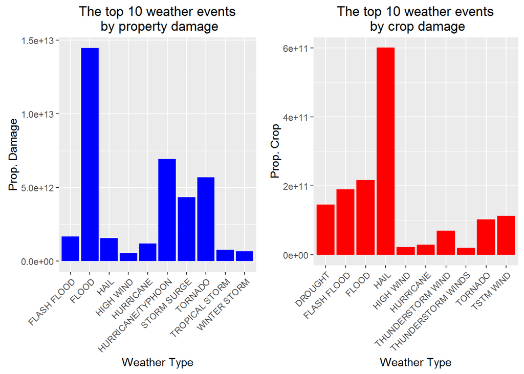

```r
plotprop <- qplot(EVTYPE, data = damagedProps, weight = TOTALPROPDMG, geom = "bar", fill = I("blue")) +
    scale_y_continuous("Prop. Damage") +
    theme(axis.text.x = element_text(angle = 45,
    hjust = 1)) + xlab("Weather Type") +
    ggtitle("The top 10 weather events\n by property damage")

plotcrop <- qplot(EVTYPE, data = damagedCrops, weight = TOTALCROPDMG, geom = "bar", fill = I("red")) +
    scale_y_continuous("Prop. Crop") +
    theme(axis.text.x = element_text(angle = 45,
    hjust = 1)) + xlab("Weather Type") +
    ggtitle("The top 10 weather events\n by crop damage")
grid.arrange(plotprop, plotcrop, ncol = 2)
```

### Conclusions

Before conclusions, a comment. Different plots are presented in personal damages and economical impact so any person willing to reproduce the research can select which one fits best to their needs and select one of them accordingly.

Having said that, the conclusions of our study are:

- Tornado is the event that leads to more personal damages
- flood is the event that create more impact in Properties and Hail in Crops.

Now, it is your turn.